# Problem Set 06 Solutions

## Background

We will again use the hate crimes data we used in Problem Set 05. The FiveThirtyEight article article about those data are in the Jan. 23, 2017 article [“Higher Rates Of Hate Crimes Are Tied To Income Inequality”](https://fivethirtyeight.com/features/higher-rates-of-hate-crimes-are-tied-to-income-inequality/). This week, we will use these data to run regression models with a single **categorical** predictor (explanatory) variable **and** a single **numeric** predictor (explanatory) variable.

Remember you can knit this file to see the instructions. You can type your answers again right into this file, knit the final draft with all your answers. Please submit the `pdf` file on gradescope.

## Setup

First load the necessary packages

```r
library(ggplot2)
library(dplyr)
library(moderndive)
library(readr)
```

Copy paste and run the following in a code chunk to read in the data:

```r
hate_crimes <- read_csv("http://bit.ly/2ItxYg3")
```

Next let’s explore the `hate_crimes` data set using the `glimpse()` function from the `dplyr` package:

```r
glimpse(hate_crimes)
```

You should also take a look at the data in the **data viewer**.

Each case/row in these data is a state in the US. This week we will consider the response variable `income`, which is the numeric variable of median income of households in each state.

We will use

# Income, education and urbanization

We will start by modeling the relationship between:

- $y$: Median household income in 2016
- $x_1$: numerical variable percent of adults 25 and older with a high-school degree, contained in the `hs` variable
- $x_2$: categorical variable level of urbanization in a state: `low`, or `high`, as contained in the variable `urbanization`

# Question 1

Create a data visualization comparing median household `income` at “low” and “high” levels of urbanization (you do not need to include the `hs` variable in this plot). Please include axis labels and title.

**Answer:**

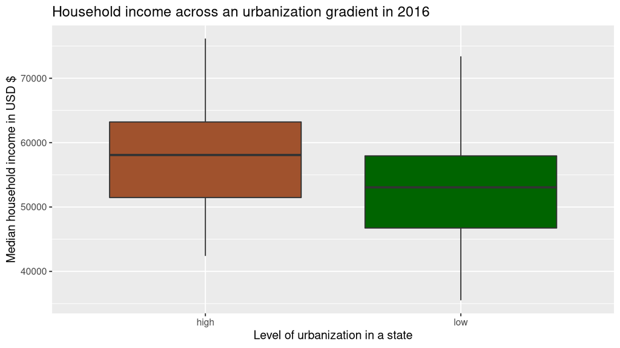

```r
ggplot(data = hate_crimes, aes(x = urbanization, y = income)) +
  geom_boxplot(fill = c("sienna", "darkgreen")) +
  labs(x = "Level of urbanization in a state", y = "Median household income in USD $",
       title = "Household income across an urbanization gradient in 2016")
```

**States with a “high” level of urbanization have a higher median household income.**

# Question 2.A

Next, let’s add the high-school degree variable into the mix by creating a scatterplot showing:

- Median household `income` on the $y$ axis
- Percent of adults 25 or older with a high school degree on the $x$ axis
- The points colored by the variable `urbanization`
- A line of best fit (regression line) for each level of the variable `urbanization` (one for “low”, one for “high”)

For this question, add the regression lines to the plot using the `geom_parallel_slopes` function from the `moderndive` package. This function will draw the regression lines based on fitting a regression model with parallel slopes (i.e., with no interaction between `hs` and `urbanization`).

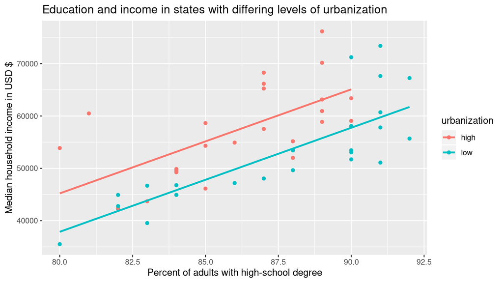

```r
ggplot(data = hate_crimes, aes(y = income, x = hs, color = urbanization)) +
  geom_point()+
  geom_parallel_slopes(se = FALSE) +
  labs(x = "Percent of adults with high-school degree",
       y = "Median household income in USD $",
       title = "Education and income in states with differing levels of urbanization"
       )
```

# Question 2.B

Do you think the relationship between `hs` and `income` is strong or weak? linear or non-linear?

**Answer:** Fairly strong, linear relationship

# Question 2.C

Which regression line (high `urbanization` or low `urbanization`) appears to have the larger intercept?

**Answer:** high urbanization

# Question 3.A

Now let’s create a second scatterplot using the same variables, but this time draw the regression lines using `geom_smooth`, which will allow for separate, non-parallel slopes for each urbanization group.

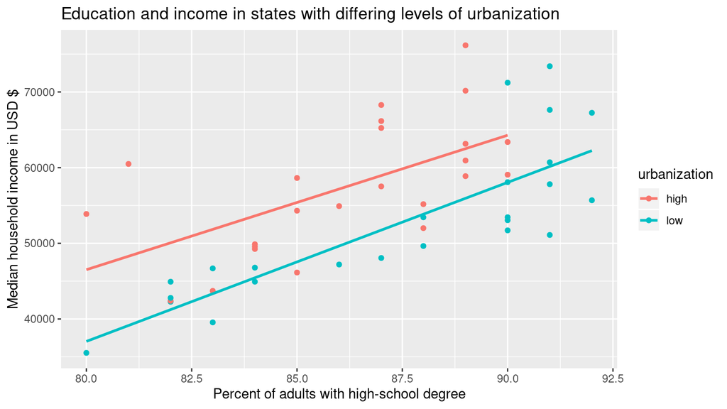

```r
ggplot(data = hate_crimes, aes(y = income, x = hs, color = urbanization)) +
  geom_point()+
  geom_smooth(method = "lm", se = FALSE) +
  labs(
    x = "Percent of adults with high-school degree",
    y = "Median household income in USD $",
    title = "Education and income in states with differing levels of urbanization")
```

# Question 3.B

How do the slopes show in the plot above compare to the slopes in Question 2? Are the two slopes fairly similar (parallel) for the two levels of urbanization, or do they differ now?

**Answer: They appear almost unchanged - the regression lines are very similar, and nearly parallel!**

# Question 3.C

Based on visually comparing the two models shown in Question 2 and Question 3, do you think it would be best to run a “parallel slopes” model (i.e. a model that estimates one shared slope for the two levels of urbanization), or a more complex “interaction model” (i.e. a model that estimates a separate slope for the two levels of urbanization)?

**Answer: I personally do not think an interaction model is warranted.**